# Sieci konwolucyjne, część I

W pierwszej części ćwiczenia zadaniem było zaimplementowanie sieci konwolucyjnej o zadanej w treści zadania architekturze, a następnie, pracując dalej z problemem rozpoznawania stylów architektonicznych na zdjęciach, dobranie odpowiednich hiperparametrów oraz sprawdzenie modyfikacji w architekturze.

## Modele

Poniżej znajdują się wykorzystane w zadaniu modele. Model 1 jest implementacją zadanej w treści zadania architektury, w Modelu 2 zwiększone zostały rozmiary filtrów konwolucyjnych, natomiat w Modelu 3 zmieniono rodzaj metody pooling na AveragePooling2D.

```python
class Model1:
  def __init__(self):

    self.model = models.Sequential()
    self.model.add(layers.Conv2D(64, (5, 5), activation='relu', input_shape=(64, 64, 3)))
    self.model.add(layers.MaxPooling2D((2, 2), strides=(2, 2)))
    self.model.add(layers.Conv2D(64, (5, 5), activation='relu', input_shape=(64, 64, 64)))
    self.model.add(layers.MaxPooling2D((2, 2), strides=(2, 2)))
    self.model.add(layers.Flatten())
    self.model.add(layers.Dense(384, activation='relu'))
    self.model.add(layers.Dense(192, activation='relu'))
    self.model.add(layers.Dense(14, activation='softmax'))

    self.name = 'Model1'
    self.history = None
    self.params = None


class Model2:
  def __init__(self):

    self.model = models.Sequential()
    self.model.add(layers.Conv2D(64, (10, 10), activation='relu', input_shape=(64, 64, 3)))
    self.model.add(layers.MaxPooling2D((2, 2), strides=(2, 2)))
    self.model.add(layers.Conv2D(64, (10, 10), activation='relu', input_shape=(64, 64, 64)))
    self.model.add(layers.MaxPooling2D((2, 2), strides=(2, 2)))
    self.model.add(layers.Flatten())
    self.model.add(layers.Dense(384, activation='relu'))
    self.model.add(layers.Dense(192, activation='relu'))
    self.model.add(layers.Dense(14, activation='softmax'))

    self.name = 'Model2'
    self.history = None
    self.params = None


class Model3:
  def __init__(self):

    self.model = models.Sequential()
    self.model.add(layers.Conv2D(64, (5, 5), activation='relu', input_shape=(64, 64, 3)))
    self.model.add(layers.AveragePooling2D((2, 2), strides=(2, 2)))
    self.model.add(layers.Conv2D(64, (5, 5), activation='relu', input_shape=(64, 64, 64)))
    self.model.add(layers.AveragePooling2D((2, 2), strides=(2, 2)))
    self.model.add(layers.Flatten())
    self.model.add(layers.Dense(384, activation='relu'))
    self.model.add(layers.Dense(192, activation='relu'))
    self.model.add(layers.Dense(14, activation='softmax'))

    self.name = 'Model3'
    self.history = None
    self.params = None
```

## Szukanie hiperparametrów

Podczas szukania najlepszych hiperparametrów sprawdzono poniższe wartości:

- optymalizator: Adam, SGD,
- współczynnik uczenia: 0.001, 0.005,
- rozmiar paczki: 100, 500,
- liczba epok: 50.

Dodatkowo w celu przyśpieszenia badań zastosowana została zasada wczesnego zatrzymania - jeżeli w 10 kolejnych epokach nie nastąpi poprawa metryki F1 na zbiorze walidacyjnym o conajmniej 0.001, to uczenie sieci zostaje zatrzymane.

W poniższej tabeli przedstawiono wyniki wszystkich modeli posortowane ze względu na wartość metryki F1 na zbiorze walidacyjnym:

```python
# full code in notebook
```

|  | index | model | optimizer | lr | epochs | batch | best_val_loss | best_val_acc | best_val_f1 |
| --- | --- | --- | --- | --- | --- | --- | --- | --- | --- |
| 1 | 1 | Model1 | adam | 0.001 | 50 | 500 | 4.602195 | 0.361673 | 0.360327 |
| 0 | 0 | Model1 | adam | 0.001 | 50 | 100 | 4.511990 | 0.365722 | 0.345643 |
| 17 | 17 | Model3 | adam | 0.001 | 50 | 500 | 5.256276 | 0.348178 | 0.343730 |
| 16 | 16 | Model3 | adam | 0.001 | 50 | 100 | 5.063066 | 0.353914 | 0.341240 |
| 9 | 9 | Model2 | adam | 0.001 | 50 | 500 | 4.498016 | 0.329285 | 0.322321 |
| 8 | 8 | Model2 | adam | 0.001 | 50 | 100 | 6.245474 | 0.319838 | 0.301256 |
| 14 | 14 | Model2 | sgd | 0.005 | 50 | 100 | 2.554244 | 0.308030 | 0.255947 |
| 6 | 6 | Model1 | sgd | 0.005 | 50 | 100 | 2.544749 | 0.293185 | 0.254688 |
| 22 | 22 | Model3 | sgd | 0.005 | 50 | 100 | 2.544474 | 0.267544 | 0.222393 |
| 18 | 18 | Model3 | adam | 0.005 | 50 | 100 | 4.748965 | 0.242915 | 0.217943 |
| 15 | 15 | Model2 | sgd | 0.005 | 50 | 500 | 2.588267 | 0.229757 | 0.159180 |
| 23 | 23 | Model3 | sgd | 0.005 | 50 | 500 | 2.594652 | 0.220985 | 0.153838 |
| 12 | 12 | Model2 | sgd | 0.001 | 50 | 100 | 2.603678 | 0.235155 | 0.149444 |
| 4 | 4 | Model1 | sgd | 0.001 | 50 | 100 | 2.574177 | 0.233131 | 0.134496 |
| 20 | 20 | Model3 | sgd | 0.001 | 50 | 100 | 2.600420 | 0.208165 | 0.109635 |
| 21 | 21 | Model3 | sgd | 0.001 | 50 | 500 | 2.628881 | 0.168016 | 0.045125 |
| 5 | 5 | Model1 | sgd | 0.001 | 50 | 500 | 2.648243 | 0.168016 | 0.033735 |
| 13 | 13 | Model2 | sgd | 0.001 | 50 | 500 | 2.619719 | 0.169366 | 0.031089 |
| 7 | 7 | Model1 | sgd | 0.005 | 50 | 500 | 2.589274 | 0.168016 | 0.020540 |
| 11 | 11 | Model2 | adam | 0.005 | 50 | 500 | 13.409997 | 0.168016 | 0.020529 |
| 3 | 3 | Model1 | adam | 0.005 | 50 | 500 | 13.409997 | 0.168016 | 0.020529 |
| 19 | 19 | Model3 | adam | 0.005 | 50 | 500 | 13.409997 | 0.168016 | 0.020529 |
| 10 | 10 | Model2 | adam | 0.005 | 50 | 100 | 13.409995 | 0.168016 | 0.020490 |
| 2 | 2 | Model1 | adam | 0.005 | 50 | 100 | 2.560050 | 0.168016 | 0.020490 |

Przebieg uczenia wszystkich modeli można znaleźć w załączniku Zal_1.html

## Najlepszy model

Najlepiej sprawdziła się architektura zadana w treści zadania. Poniżej przedstawiono jej szczegóły oraz najlepsze znalezione parametry wraz z przebiegiem uczenia:

```
--------MODEL--------

Model1

Model: "sequential_1"
_________________________________________________________________
Layer (type)                 Output Shape              Param #
=================================================================
conv2d_2 (Conv2D)            (None, 60, 60, 64)        4864
_________________________________________________________________
max_pooling2d_2 (MaxPooling2 (None, 30, 30, 64)        0
_________________________________________________________________
conv2d_3 (Conv2D)            (None, 26, 26, 64)        102464
_________________________________________________________________
max_pooling2d_3 (MaxPooling2 (None, 13, 13, 64)        0
_________________________________________________________________
flatten_1 (Flatten)          (None, 10816)             0
_________________________________________________________________
dense_3 (Dense)              (None, 384)               4153728
_________________________________________________________________
dense_4 (Dense)              (None, 192)               73920
_________________________________________________________________
dense_5 (Dense)              (None, 14)                2702
=================================================================
Total params: 4,337,678
Trainable params: 4,337,678
Non-trainable params: 0
_________________________________________________________________
None

Optimizer:  adam
Learning rate:  0.001
Epochs:  50
Batch:  500

Best validation Loss:  4.602194786071777
Best validation Accuracy:  0.36167341470718384
Best validation F1Score:  0.3603273928165436
```

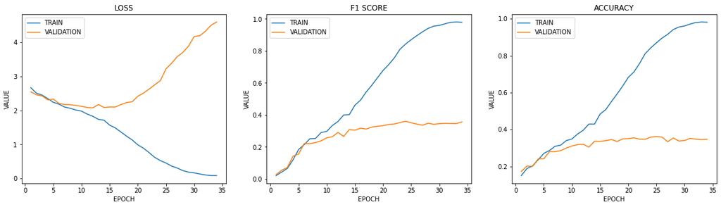

```python
# full code in notebook
```

Działanie modelu sprawdzono na zbiorze testowym:

```python
# full code in notebook
```

```
Test F1: 0.38144226453051117
```

Sprawdzono również macierz pomyłek:

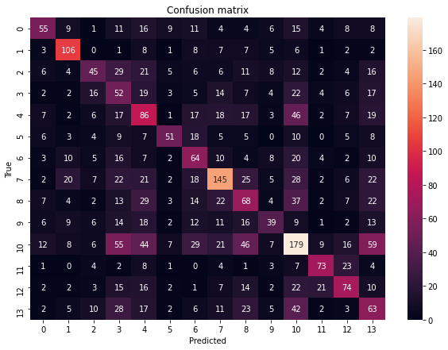

```python
# full code in notebook
```

Na koniec wyświetlono przykładowe błędne oraz poprawne klasyfikacje:

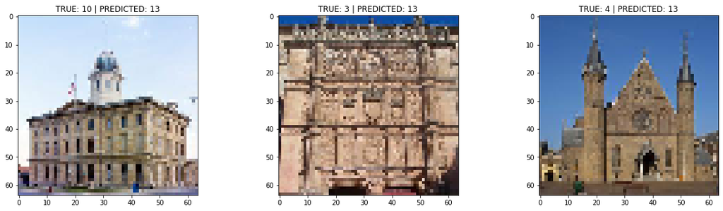

```python
# full code in notebook
```

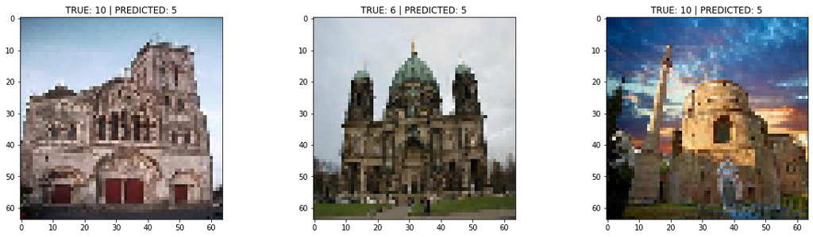

```python
# full code in notebook
```

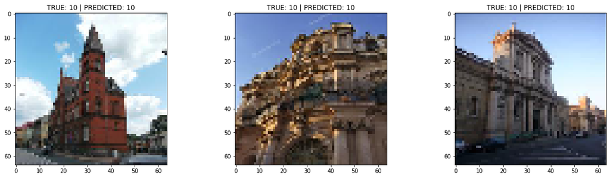

```python
# full code in notebook
```